# Module 4, Lesson 3: Towards ggplot2 mastery

In this final (and *bonus* – meaning it does not have an accompanying guided practice video) independent guide, we will walk through some more complex functions within `ggplot2` that allow you to not only re-create the content in Figure 1.1 of The Global Findex Database 2017 but also all of the same details: color scheme, labels, etc.

This content is beyond the scope of what we could practically cover in the course, which means much of it will be non-intuitive at first. The goal here is help jumpstart your own self-directed learning by offering more advanced examples within a context you are already familiar with.

We first re-create the approximation to Figure 1.1 that we came up with by the end of Module 3:

```r
library(tidyverse)
micro_world <-
  read_csv("micro_world.csv")
micro_world_account <-
  micro_world %>%
  group_by(economycode) %>%
  summarize(account =
              100 * weighted.mean(account, w = wgt))

wb_income <-
  read_csv("wb_income.csv")
account_by_income <-
  left_join(micro_world_account,
            wb_income)
```

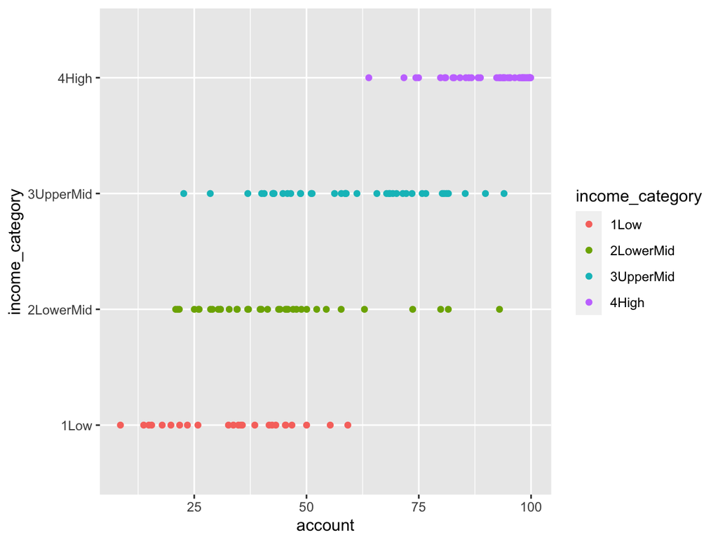

**Image description: Initial approximation of Figure 1.1 from The Global Findex Database 2017**

```r
ggplot(data = account_by_income,
       mapping = aes(x = account,
                     y = income_category,
                     color = income_category)) +
  geom_point()
```

Compare this to the published version of Figure 1.1 from The Global Findex Database 2017, reproduced here:

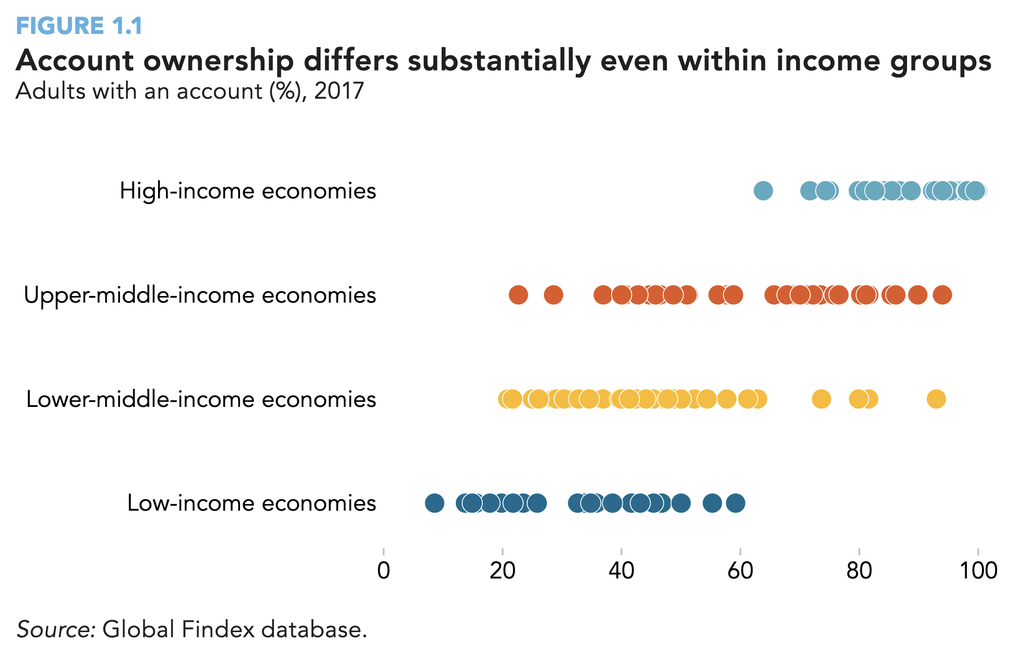

**Image description: Figure 1.1 from The Global Findex Database 2017** (source: https://openknowledge.worldbank.org/handle/10986/29510)

To be sure, our plot and Figure 1.1 are clearly plotting the same data. However, if our goal was to replicate Figure 1.1, we fell short. In the following sections, we will make incremental changes to our code to more precisely replicate Figure 1.1. The list of changes we’ll make are as follows:

1. Change the type and size of the points that are plotted
2. Add a title, subtitle, and caption to the plot
3. Drop the color legend on the right, match the color scheme
4. Increase the size of the text, drop the grey background, and make other minor modifications to formatting

## 1. Change point-type, size

Putting this all together, Step 1 of our improvements are implemented with the following code.

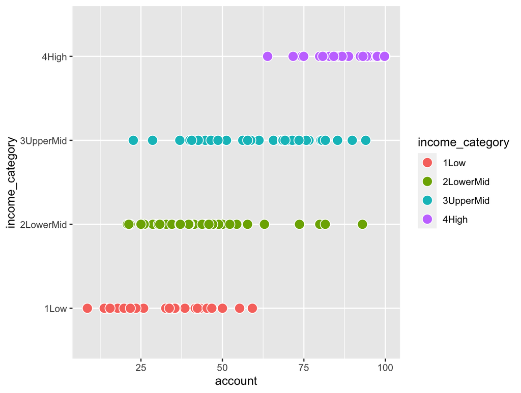

**Image description: Step 1 for updating Figure 1.1 from The Global Findex Database 2017**

```r
figure1.1_step1 <-
  ggplot(data = account_by_income,
         mapping = aes(x = account,
                       y = income_category,
                       fill = income_category)) +
  geom_point(shape = 21, color = "#FFFFFF", size = 4)
figure1.1_step1
```

If you are not familiar with hexidecimal (hex) representation of colors, the code `color = "#FFFFFF"` may look strange. Hex codes are formal ways of specifying colors on computers. They are comprised of the number sign (`#`) followed by any combination of the numbers 0-9 or the letters A-F. The code `"#FFFFFF"` is the hex code for the color white. You can read more about hex codes on [Wikipedia](https://en.wikipedia.org/wiki/Web_colors#Hex_triplet).

There are a limited number of colors written as strings that R will recognize, `"white"` being one of them. So, you could also write `color = "white"` in the code above and get the same result. If you type `colors()` in your R console and press Enter, you will see the entire set of colors that you can write as a string.

## 2. Titles, subtitle, and caption

To add a title, subtitle, and caption, we use the `labs` function from Module 3, Lesson 3. In that lesson, we practiced changing the labels for aesthetics, e.g. `x = <XLABEL>` AND `y = <YLABEL>`. But `labs` also allows you to change the title (`title = <TITLE>`), subtitle (`subtitle = <SUBTITLE>`), and caption (`caption = <CAPTION>`).

We also want to change the number and nature of the tick marks on the x and y axes. Specifically, as you practiced in the Practice Quiz for Module 3, Lesson 3, we want to extend the limits of the x-axis to cover the smallest and largest possible of 0 and 100 (`limits = c(0, 100)`), respectively, and we want the tick marks to land at every increment of 20 (`breaks = c(0, 20, 40, 60, 80, 100)`).

As for the y-axis, we don’t want to change the number or position of the tick marks but rather the labels for the existing tick marks. This is achieved by providing a so-called “named vector”: `c(<VALUE1> = <LABEL1>, <VALUE2> = <LABEL2>, ...)` The VALUES should be the the values from your variable; in our case we have four: `4High`, `3UpperMid`, `2LowerMid`, and `1Low`. And the LABELS can be whatever you want to actually be shown.

Putting this all together, Step 2 of our improvements are implemented with the following code:

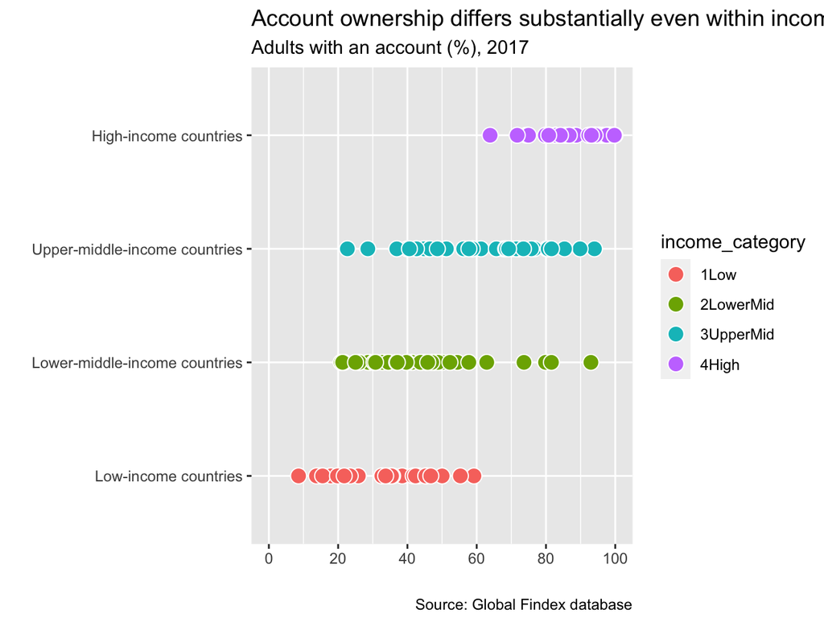

**Image description: Step 2 for updating Figure 1.1 from The Global Findex Database 2017**

```r
figure1.1_step2 <-
  figure1.1_step1 +
  scale_x_continuous(limits = c(0, 100),
                     breaks = c(0, 20, 40, 60, 80, 100)) +
  scale_y_discrete(labels = c("4High" = "High-income countries",
                              "3UpperMid" = "Upper-middle-income countries",
                              "2LowerMid" = "Lower-middle-income countries",
                              "1Low" = "Low-income countries")) +
  labs(x = "", # an empty string completely suppresses the label
       y = "",
       title = "Account ownership differs substantially even within income groups",
       subtitle = "Adults with an account (%), 2017",
       caption = "Source: Global Findex database")
figure1.1_step2
```

We will address the issue with the figure title getting truncated in Step 4.

Note that what we do above is create a new ggplot2 object called `figure1.1_step2`, which starts with the improvements from step 1 and adds our further modifications. We then print the resulting new ggplot2 object `figure1.1_step2`.

## 3. Drop legend, modify colors

In this third step, we want to do two things: (a) drop the legend on the right-hand side of the plot, which is redundant because the y-axis already allows us to distinguish between each income category and (b) change the colors for each value of `income_category` to match Figure 1.1.

To modify the legend of an aesthetic, we use a `ggplot2` function called `guides`. To completely suppress the legend for a particular aesthetic, as we desire here, we would write `guides(<AESTHETIC_NAME>="none")`.

To change the colors that the `fill` aesthetic uses, we need to use a `scale` function as we did in Step 2. Specifically, because we are mapping the `fill` aesthetic, we need to use a function that starts with `scale_fill`. Different from our previous experiences, we will use a function called `scale_fill_manual`, which is a function that allows for more customization of an aesthetic’s values, since the color scheme for Figure 1.1 in The Global Findex Database 2017 is (to the best of our knowledge) not a standard color scheme. Thus, we need to provide a named vector that communicates the value of `fill` that should correspond to each value of the `income_category` variable: `c(<VALUE1> = <HEXCODE1>, <VALUE2> = <HEXCODE2>, ...)`. From top to bottom, the hex codes for the four colors are #6AA8BD, #D36033, #F3BC44, and #2D698C.

Incorporating these two extensions into our plot from Step 2, we have:

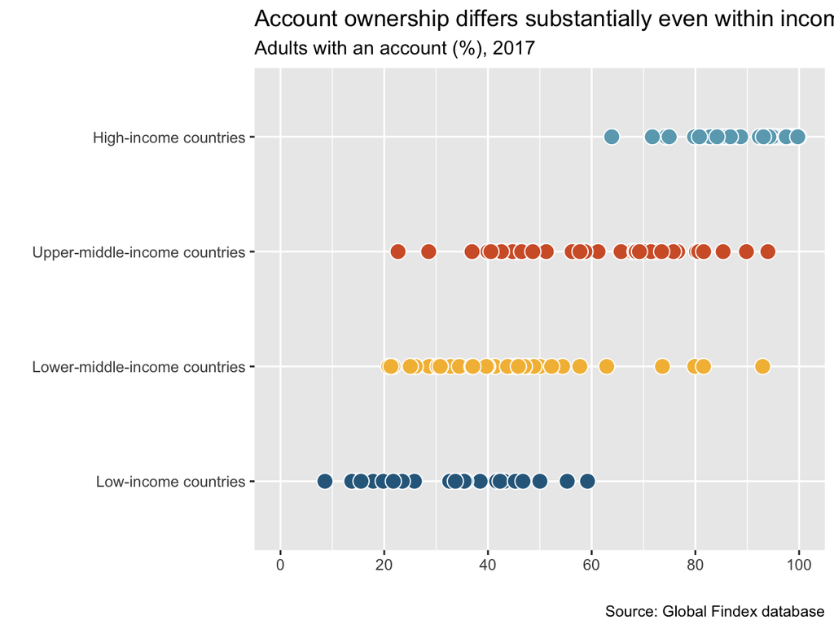

**Image description: Step 3 for updating Figure 1.1 from The Global Findex Database 2017**

```r
figure1.1_step3 <-
  figure1.1_step2 +
  scale_fill_manual(values = c("4High" = "#6AA8BD",
                               "3UpperMid" = "#D36033",
                               "2LowerMid" = "#F3BC44",
                               "1Low" = "#2D698C")) +
  guides(fill = "none")
figure1.1_step3
```

Helpfully, having now suppressed the printing of the legend for `fill`, `ggplot` automatically increases the size of the plotted panel to fill that space, making the plot seem less “squished”.

## 4. Increase text size, drop grey background

Finally, we will use the `theme` function from `ggplot2` to modify the overall appearance of the plot. The function is complicated upon first introduction, which is the cost of the flexibility it provides. Because there are so many options, we first provide the code for implementing Step 4 and then describe how to interpret what we’ve done.

```r
figure1.1_step4 <-
  figure1.1_step3 +
  theme(axis.ticks.y = element_blank(),
        axis.text = element_text(size = 11.5),
        panel.background = element_blank(),
        plot.title = element_text(face = "bold", size = 13.5),
        plot.subtitle = element_text(size = 11.5),
        plot.caption = element_text(hjust = 0),
        plot.title.position = "plot",
        plot.caption.position = "plot")
```

Inside the call to `theme`, we have made the following choices:

- `axis.ticks.y = element_blank()` means that we want to completely suppress printing of the tick marks, but only along the y-axis. If we want to suppress printing of the tick marks on the x-axis, we would use `axis.ticks.x = element_blank()`, and if we wanted to suppress printing on both axes at the same time, we could use `axis.ticks = element_blank()`
- `axis.text = element_text(size = 11.5)` means that we want to change the font size to 11.5 for all text elements related to each axis. Since we use `axis.text` and not `axis.text.x` or `axis.text.y` (which are other arguments in theme), we are changing the font size for both axes
- `panel.background = element_blank()` suppresses the grey background that is shown by default
- `plot.title = element_text(face = "bold", size = 13.5)` means that the title will be plotted in boldface and with font size 13.5
- `plot.subtitle = element_text(size = 11.5)` means that the subtitle will be plotted with font size 11.5
- `plot.caption = element_text(hjust = 0)` means that the caption will be left-justified and not right-justified (its default)
- `plot.title.position = "plot"` and `plot.caption.position = "plot"` means that the title and subtitle will be justified according to the edge of entire *plot* instead of according to the edge of the *panel* containing the data (its default)

Having implemented Step 4, our final version looks like this:

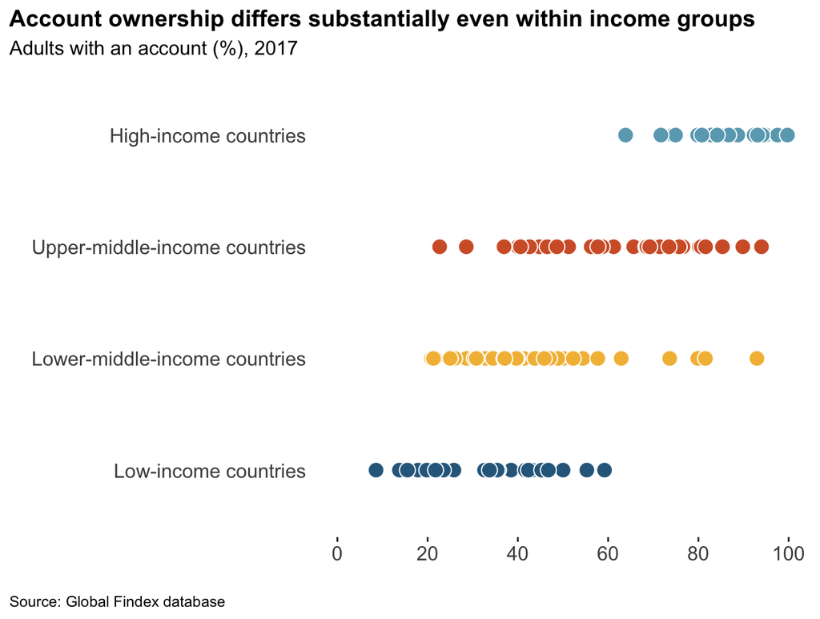

**Image description: Step 4 for updating Figure 1.1 from The Global Findex Database 2017**

```r
figure1.1_step4
```

And, for comparison, here is Figure 1.1. again:

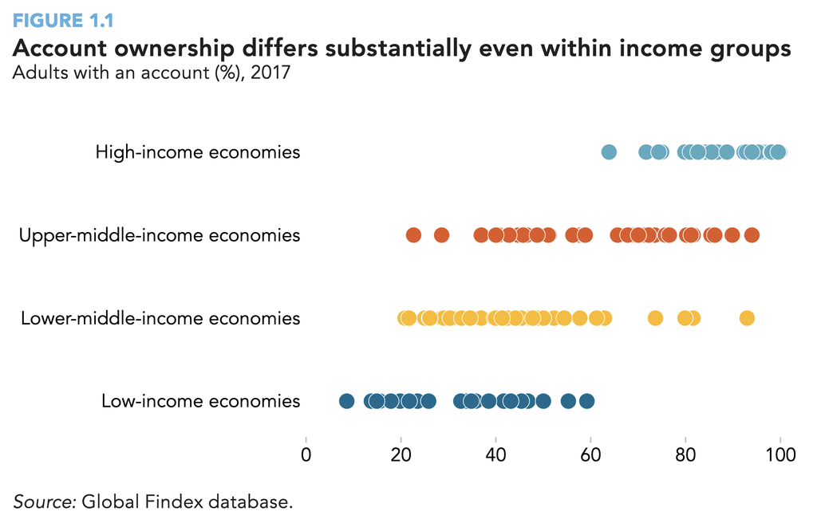

**Image description: Figure 1.1 from The Global Findex Database 2017** (source: https://openknowledge.worldbank.org/handle/10986/29510)

## Appendix

For reference, the entire code block for making our final version of the figure is given here:

```r
ggplot(data = account_by_income,
       mapping = aes(x = account,
                     y = income_category,
                     fill = income_category)) +
  geom_point(shape = 21, color = "#FFFFFF", size = 4)  +
  scale_x_continuous(limits = c(0, 100),
                     breaks = c(0, 20, 40, 60, 80, 100)) +
  scale_y_discrete(labels = c("4High" = "High-income countries",
                              "3UpperMid" = "Upper-middle-income countries",
                              "2LowerMid" = "Lower-middle-income countries",
                              "1Low" = "Low-income countries")) +
  labs(x = "", # an empty string completely suppresses the label
       y = "",
       title = "Account ownership differs substantially even within income groups",
       subtitle = "Adults with an account (%), 2017",
       caption = "Source: Global Findex database") +
  scale_fill_manual(values = c("4High" = "#6AA8BD",
                               "3UpperMid" = "#D36033",
                               "2LowerMid" = "#F3BC44",
                               "1Low" = "#2D698C")) +
  guides(fill = "none") +
  theme(axis.ticks.y = element_blank(),
        axis.text = element_text(size = 11.5),
        panel.background = element_blank(),
        plot.title = element_text(face = "bold", size = 13.5),
        plot.subtitle = element_text(size = 11.5),
        plot.caption = element_text(hjust = 0),
        plot.title.position = "plot",
        plot.caption.position = "plot")
```